# Kim_Tae-Seung

##### Section 3: (15 points)

##### (3) Performing hypothesis tests using random samples is fundamental to statistical inference. The first part of this problem involves comparing two different diets. Using “ChickWeight” data available in the base R, “datasets” package, we will create a subset of the “ChickWeight” data frame. Specifically, we want to create a data frame that includes only those rows where Time == 21 AND Diet == 1 or 3.

```r
# load "ChickWeight" dataset
data(ChickWeight, package = "datasets")

# There are multiple ways to approach the subsetting task. The method you choose is up
# to you.

s3_df <- ChickWeight[ChickWeight$Time == 21 & (ChickWeight$Diet == 1 | ChickWeight$Diet == 3),]

head(s3_df)
```

```
##    weight Time Chick Diet
## 12    205   21     1    1
## 24    215   21     2    1
## 36    202   21     3    1
## 48    157   21     4    1
## 60    223   21     5    1
## 72    157   21     6    1
```

```r
# The values in your subsetted data frame should match those below:
# > head(df)
#    weight Time Chick Diet
# 12    205   21     1    1
# 24    215   21     2    1
# 36    202   21     3    1
# 48    157   21     4    1
# 60    223   21     5    1
# 72    157   21     6    1
```

##### The data frame, “result”, has chick weights for two diets, identified as diet “1” and “3”. Use the data frame, “result,” to complete the following item.

(3)(a) (3 points) Display two side-by-side vertical boxplots using par(mfrow = c(1,2)). One boxplot would display Diet “1” and the other Diet “3”.

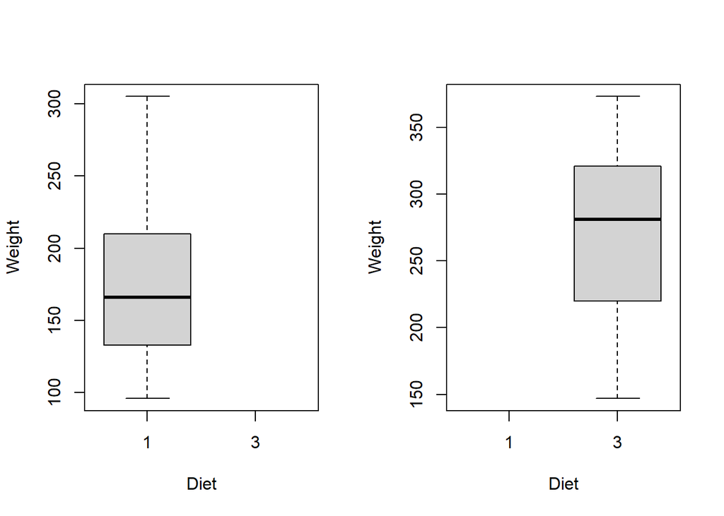

```r
par(mfrow = c(1,2))
boxplot(weight ~ droplevels(Diet), data= s3_df, subset = Diet=="1", xlab = 'Diet', ylab = 'Weight')

boxplot(weight ~ droplevels(Diet), data= s3_df, subset = Diet=="3", xlab = 'Diet', ylab = 'Weight')
```

(3)(b) (3 points) Use the “weight” data for the two diets to test the null hypothesis of equal population mean weights for the two diets. Test at the 95% confidence level with a two-sided t-test. This can be done using *t.test()* in R. Assume equal variances. Display the results of *t.test()*.

```r
t.test(s3_df$weight ~ s3_df$Diet, var.equal = TRUE)
```

```
##
##  Two Sample t-test
##
## data:  s3_df$weight by s3_df$Diet
## t = -3.5955, df = 24, p-value = 0.001454
## alternative hypothesis: true difference in means between group 1 and group 3 is not equal to 0
## 95 percent confidence interval:
##  -145.67581  -39.42419
## sample estimates:
## mean in group 1 mean in group 3
##          177.75          270.30
```

##### Working with paired data is another common statistical activity. The “ChickWeight” data will be used to illustrate how the weight gain from day 20 to 21 may be analyzed. This time, we will look only at those individuals on Diet == “3”. You will need to add code below creating two (2) vectors. One (1) vector should include all the Time == 20 weights of those individuals on Diet == “3”; a second should include all the Time == 21 weights of those individuals on Diet == “3”.

```r
# There are multiple ways to approach the subsetting task. The method you choose is up
# to you.


only20 <- ChickWeight[ChickWeight$Diet == 3 & ChickWeight$Time == 20,"weight"]
only21 <- ChickWeight[ChickWeight$Diet == 3 & ChickWeight$Time == 21,"weight"]
s3_df2 <- data.frame(only20,only21)

only20[1:6]
```

```
## [1] 235 291 156 327 361 225
```

```r
# The first six (6) elements of your Time == 20 vector should match those below:
# [1] 235 291 156 327 361 225
```

(3)(c) (3 points) Present a scatterplot of the Time == 21 weights as a function of the Time == 20 weights. Include a diagonal line with zero intercept and slope equal to one. Title and label the variables in this scatterplot.

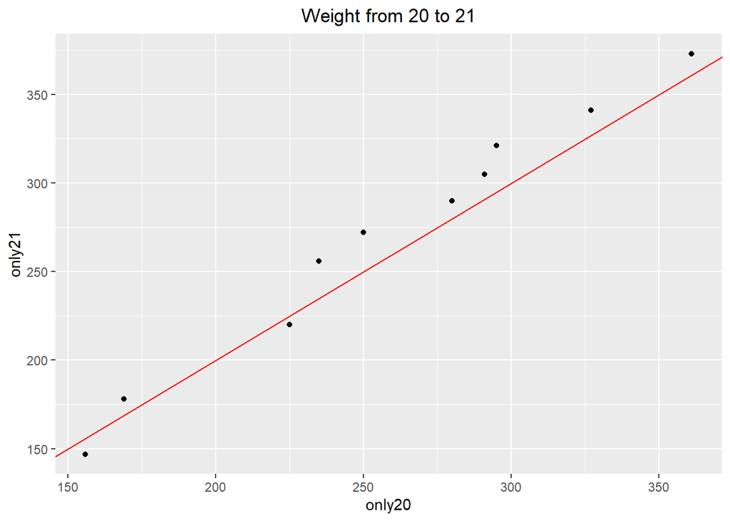

```r
ggplot(data =s3_df2,aes(x=only20,y=only21)) +
  geom_point() +
  geom_abline(intercept=0, slope=1, color= 'red') +
  ggtitle('Weight from 20 to 21') +
  theme(plot.title = element_text(hjust = 0.5))
```

(3)(d) (6 points) Calculate and present a one-sided, 95% confidence interval for the average weight gain from day 20 to day 21. Write the code for the paired t-test and for determination of the confidence interval endpoints. **Do not use *t.test()**, although you may check your answers using this function. Present the resulting test statistic value, critical value, p-value and confidence interval.

```r
s3_df2_diff <- s3_df2$only21 - s3_df2$only20

t_stat <- mean(s3_df2_diff) / (sd(s3_df2_diff) / sqrt(length(s3_df2_diff)))

p_val <- pt(q = t_stat, df= length(s3_df2_diff)-1, lower.tail = FALSE)

crit_t_val <- qt(p = 0.95, df = length(s3_df2_diff)-1)

lower <- mean(s3_df2_diff) - crit_t_val * sd(s3_df2_diff) / sqrt(length(s3_df2_diff))

list("t stat" = t_stat,
     "p val" = p_val,
     "crit t" = crit_t_val,
     "conf int" = list(lower=lower, upper = "inf"))
```

```
## $`t stat`
## [1] 3.225267
##
## $`p val`
## [1] 0.00520061
##
## $`crit t`
## [1] 1.833113
##
## $`conf int`
## $`conf int`$lower
## [1] 4.920696
##
## $`conf int`$upper
## [1] "inf"
```

##### Section 4: (15 points)

##### (4) Statistical inference depends on using a sampling distribution for a statistic in order to make confidence statements about unknown population parameters. The Central Limit Theorem is used to justify use of the normal distribution as a sampling distribution for statistical inference. Using Nile River flow data from 1871 to 1970, this problem demonstrates sampling distribution convergence to normality. Use the code below to prepare the data. Refer to this example when completing (4)(c) below.

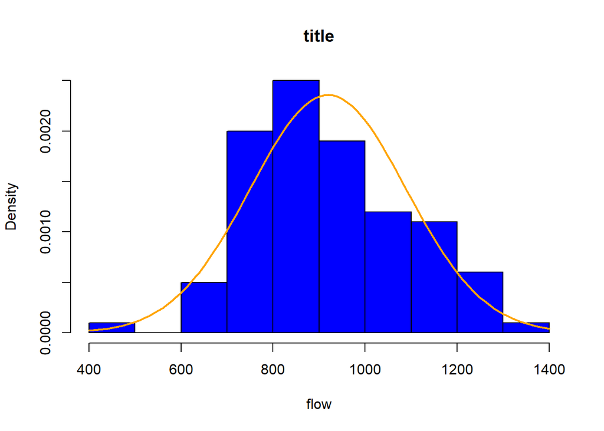

```r
data(Nile, package = "datasets")

s4_mean <- mean(Nile)
s4_std <- sd(Nile)

s4_x <- c(seq(400,1400,1))

hist(Nile, freq = FALSE, col = 'blue', xlab= 'flow', main = 'title')
curve(dnorm(x,mean = s4_mean, sd = s4_std), col = 'orange', lwd=2, add=TRUE)
```

(4)(a) (3 points) Using Nile River flow data and the “moments” package, calculate skewness and kurtosis. Present a QQ plot and boxplot of the flow data side-by-side using *qqnorm()*, *qqline()* and *boxplot()*; *par(mfrow = c(1, 2))* may be used to locate the plots side-by-side. Add features to these displays as you choose.

```r
skewness(Nile)
```

```
## [1] 0.3223697
```

```r
kurtosis(Nile)
```

```
## [1] 2.695093
```

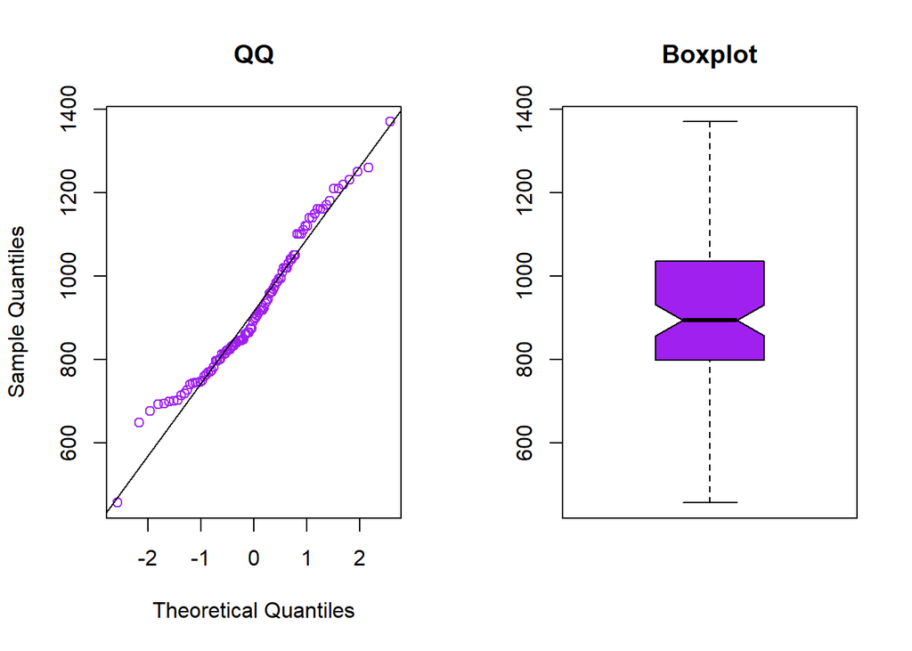

```r
par(mfrow = c(1, 2))
qqnorm(Nile, col = 'purple', main = c("QQ"))
qqline(Nile)

boxplot(Nile, col = 'purple', main = c("Boxplot"), notch = TRUE)
```

```r
set.seed(124)

s4b_n <- 1000

sample1 <- c()
sample2 <- c()



for (i in 1:s4b_n) {
  s4b_samp <- sample(Nile, 16, replace = TRUE)
  sample1 <- c(sample1,mean(s4b_samp))
  }

sam1_mean <- mean(sample1)
sam1_std <- sd(sample1)
sam1_var <- var(sample1)

sam1_holder <- c('sample1', sam1_mean, sam1_std, sam1_var)

samp1_df <- data.frame(t(sam1_holder))

set.seed(127)

for (j in 1:s4b_n) {
  s4b_samp <- sample(Nile, 16, replace = TRUE)
  sample2 <- c(sample2,mean(s4b_samp))
  }

sam2_mean <- mean(sample2)
sam2_std <- sd(sample2)
sam2_var <- var(sample2)

sam2_holder <- c('sample2', sam2_mean, sam2_std, sam2_var)
samp2_df <- data.frame(t(sam2_holder))

col_name <- c('Sample','Mean','Std Dev', 'Variance')

s4b_df <- rbind(samp1_df,samp2_df)
colnames(s4b_df) <- col_name
s4b_df
```

```
##    Sample        Mean          Std Dev         Variance
## 1 sample1 918.7364375 42.0015622619837 1764.13123244729
## 2 sample2 917.9954375 40.8539515416981 1669.04535657142
```

(4)(c) (6 points) Present side-by-side histograms of “sample1” and “sample2” with the normal density curve superimposed. To prepare comparable histograms, it will be necessary to use “freq = FALSE” and to maintain the same x-axis with “xlim = c(750, 1050)”, and the same y-axis with “ylim = c(0, 0.025).” **To superimpose separate density functions, you will need to use the mean and standard deviation for each “sample” - each histogram - separately.**

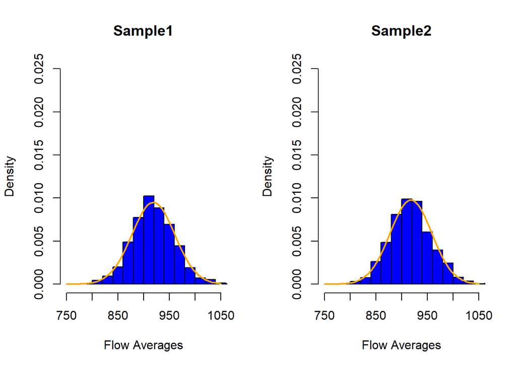

```r
# Create histograms of "sample1" and "sample2" with normal density curves superimposed

par(mfrow = c(1,2))

hist(sample1, freq= FALSE, col = 'blue', xlab = 'Flow Averages', xlim = c(750,1050), ylim = c(0,0.025), main = "Sample1")
curve(dnorm(x,mean = sam1_mean, sd = sam1_std), col = 'orange', lwd=2, add=TRUE)


hist(sample2, freq= FALSE, col = 'blue', xlab = 'Flow Averages', xlim = c(750,1050), ylim = c(0,0.025), main = "Sample2")
curve(dnorm(x,mean = sam2_mean, sd = sam2_std), col = 'orange', lwd=2, add=TRUE)
```

##### Section 5: (15 points)

##### (5) This problem deals with contingency table analysis. This is an example of categorical data analysis (see Kabacoff, pp. 145-151). The “warpbreaks” dataset gives the number of warp breaks per loom, where a loom corresponds to a fixed length of yarn. There are 54 observations on 3 variables: breaks (numeric, the number of breaks), wool (factor, type of wool: A or B), and tension (factor, low L, medium M and high H). These data have been studied and used for example elsewhere. For the purposes of this problem, we will focus on the relationship between breaks and tension using contingency table analysis.

(5)(a)(5 points) warpbreaks is part of the “datasets” package and may be loaded via *data(warpbreaks)*. Load “warpbreaks” and present the structure using *str()*. Calculate the median number of breaks for the entire dataset, disregarding “tension” and “wool”. Define this median value as “median_breaks”. Present a histogram of the number of breaks with the location of the median indicated.

Create a new variable “number” as follows: for each value of “breaks”, classify the number of breaks as either strictly below “median_breaks”, or the alternative. Convert the “above”|“below” classifications to a factor, and combine with the dataset warpbreaks. Present a summary of the augmented dataset using *summary()*. Present a contingency table of the frequency of breaks using the two variables “tension” and “number”. There should be six cells in this table.

```r
data(warpbreaks, package = "datasets")
str(warpbreaks)
```

```
## 'data.frame':    54 obs. of  3 variables:
##  $ breaks : num  26 30 54 25 70 52 51 26 67 18 ...
##  $ wool   : Factor w/ 2 levels "A","B": 1 1 1 1 1 1 1 1 1 1 ...
##  $ tension: Factor w/ 3 levels "L","M","H": 1 1 1 1 1 1 1 1 1 2 ...
```

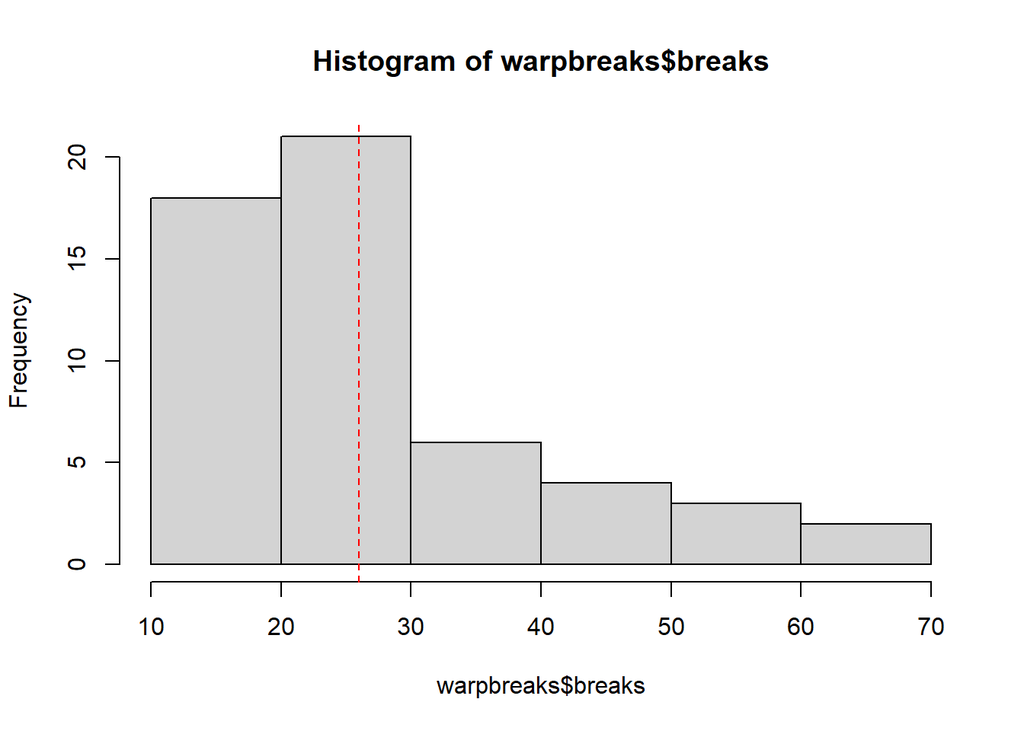

```r
median_breaks <- median(warpbreaks$breaks)

hist(warpbreaks$breaks)
abline(v = median_breaks, lty = 2, col = 'red')
```

```r
warpbreaks$number <- factor(ifelse(warpbreaks$breaks < median_breaks,"below","above"))

summary(warpbreaks)
```

```
##      breaks      wool   tension   number
##  Min.   :10.00   A:27   L:18    above:29
##  1st Qu.:18.25   B:27   M:18    below:25
##  Median :26.00          H:18
##  Mean   :28.15
##  3rd Qu.:34.00
##  Max.   :70.00
```

```r
s5_table <- table(warpbreaks$tension,warpbreaks$number)
s5_table
```

```
##
##     above below
##   L    14     4
##   M    10     8
##   H     5    13
```

(5)(b)(3 points) Using the table constructed in (5)(a), test at the 5% level the null hypothesis of independence using the uncorrected *chisq.test()* (Black, Business Statistics, Section 16.2). Show the results of this test and state your conclusions.

```r
chisq.test(x = s5_table, correct= FALSE)
```

```
##
##  Pearson's Chi-squared test
##
## data:  s5_table
## X-squared = 9.0869, df = 2, p-value = 0.01064
```

```r
#conclusion: the relationship is worth looking at. Since p < 0.05, we can reject the null hypothesis of the chisq test (tension and number are independent). This means we can assert that they are dependent.
```

(5)(c) (3 points) ‘Manually’ calculate the chi-squared statistic and p-value of the table from (5)(a). The *addmargins()* function can be used to add row and column sums to the table; useful for calculating the expected values for each cell. You should be able to match the chi-squared and p-values from (5)(b). The underlying code for the *chisq.test()* function can be viewed by entering *chisq.test* - without parentheses - in the Console. You are given code below to create the table, add row and column sums and calculate the expected values for the for the first two (2) of three (3) rows. You will need to add code to calculate the expected values for the third row and the chi-squared. The *pchisq()* function can be used to return the p-value.

```r
tbl <- table(warpbreaks$tension, warpbreaks$number)
mar_tbl <- addmargins(tbl)
mar_tbl
```

```
##
##       above below Sum
##   L      14     4  18
##   M      10     8  18
##   H       5    13  18
##   Sum    29    25  54
```

```r
e11 <- mar_tbl[4, 1] * mar_tbl[1, 3] / mar_tbl[4, 3]
e12 <- mar_tbl[4, 2] * mar_tbl[1, 3] / mar_tbl[4, 3]
e21 <- mar_tbl[4, 1] * mar_tbl[2, 3] / mar_tbl[4, 3]
e22 <- mar_tbl[4, 2] * mar_tbl[2, 3] / mar_tbl[4, 3]
e31 <- mar_tbl[4, 1] * mar_tbl[3, 3] / mar_tbl[4, 3]
e32 <- mar_tbl[4, 2] * mar_tbl[3, 3] / mar_tbl[4, 3]


chi_sq <- (tbl[1,1] - e11)^2 / e11 +
  (tbl[1,2] - e12)^2 / e12 +
  (tbl[2,1] - e21)^2 / e21 +
  (tbl[2,2] - e22)^2 / e22 +
  (tbl[3,1] - e31)^2 / e31 +
  (tbl[3,2] - e32)^2 / e32

list ('chisq' = chi_sq,
      'p-val' = pchisq(q=chi_sq, df = (nrow(tbl)-1 * (ncol(tbl)-1)), lower.tail = FALSE))
```

```
## $chisq
## [1] 9.086897
##
## $`p-val`
## [1] 0.01063667
```

```r
chisq_function <- function(x) {
  # Code for calculating the expected values
  mar_tbl <- addmargins(x)
  e11 <- mar_tbl[4, 1] * mar_tbl[1, 3] / mar_tbl[4, 3]
  e12 <- mar_tbl[4, 2] * mar_tbl[1, 3] / mar_tbl[4, 3]
  e21 <- mar_tbl[4, 1] * mar_tbl[2, 3] / mar_tbl[4, 3]
  e22 <- mar_tbl[4, 2] * mar_tbl[2, 3] / mar_tbl[4, 3]
  e31 <- mar_tbl[4, 1] * mar_tbl[3, 3] / mar_tbl[4, 3]
  e32 <- mar_tbl[4, 2] * mar_tbl[3, 3] / mar_tbl[4, 3]

  # Code for calculating the chi-squared
  chi_sq <- (tbl[1,1] - e11)^2 / e11 +
  (tbl[1,2] - e12)^2 / e12 +
  (tbl[2,1] - e21)^2 / e21 +
  (tbl[2,2] - e22)^2 / e22 +
  (tbl[3,1] - e31)^2 / e31 +
  (tbl[3,2] - e32)^2 / e32


  # Code for calculating the degrees of freedom and p-value
  s5_df = (nrow(x)-1 * (ncol(x)-1))
  s5_pv = pchisq(q=chi_sq, s5_df, lower.tail = FALSE)
  # Code to ouput the chi-squared, degrees of freedom and p-value
  list ('chisq' = chi_sq,
      'p-val' = s5_pv)
}

chisq_function(tbl)
```

```
## $chisq
## [1] 9.086897
##
## $`p-val`
## [1] 0.01063667
```

You do not need to do anything with the below. It is provided only for demonstration purposes. In (5)(d), we know the size of the table - 3 x 2 - and write a function to match. Often, though, we’ll want to write functions that are flexible in some way.

```r
# Below is a function that should return the same values as chisq.test() and your
# function from (5)(d). Here, though, the function loops over the rows and columns
# to calculate the expected values. Ideally, this function would work for any sized
# table.

chisqfun <- function(t) {
   x <- addmargins(t)
   e <- matrix(0, nrow = nrow(t), ncol = ncol(t), byrow = T)
   r <- matrix(0, nrow = nrow(t), ncol = ncol(t), byrow = T)
   for (i in 1:dim(t)[1]) {
       for (j in 1:dim(t)[2]) {
          e[i,j] = x[nrow(x),j] * x[i,ncol(x)]/x[nrow(x), ncol(x)]
         r[i,j] = ((x[i,j] - e[i,j])^2)/e[i,j]
         }
     }
  chi <- sum(r)
  xdf <- (nrow(t) - 1) * (ncol(t) - 1)
  pv <- pchisq(chi, df = xdf, lower.tail = FALSE)
  return(list("chi-squared" = chi, "degrees_of_freedom" = xdf, "p-value" = pv))
  }
```